# sampling

# `sample_*` functions

- `sample_srs()` - simple random sampling
- `sample_systematic()`- systematic sampling in a grid or hexagon tessellation
- `sample_strat()` - stratified sampling within a `sraster`
- `sample_clhs()` - Latin hypercube sampling algorithm
- `sample_balanced()` - see [BalancedSampling](http://www.antongrafstrom.se/balancedsampling/)

## Access

A feature of the `sample_*` functions is the ability to define `access` corridors. Users can supply a road access network (must be `sf` line objects) and define buffers around `access` where samples should be excluded and included.

Important additional parameters when `access` is provided are:

- `buff_inner` - An inner buffer that defines the distance from `access` where samples cannot be taken (i.e. if you don’t want samples within 50 m of your `access` layer set `buff_inner = 50`).
- `buff_outer` - Maximum distance samples can be located from `access` (i.e. if you don’t want samples more than 200 meters from your `access` layer set `buff_inner = 200`)

## `sample_srs`

We provided a very simple example of using the `sample_srs()` function in `vignette("sgsR")`. We provide some additional examples below.

Notice that the input for `sample_srs()` is `raster`. This means that either `sraster` or an `mraster` are supported.

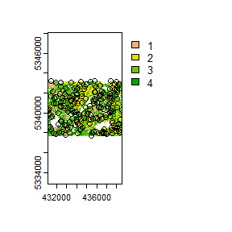

```
#> Simple feature collection with 200 features and 0 fields
#> Geometry type: POINT
#> Dimension:     XY
#> Bounding box:  xmin: 431110 ymin: 5337730 xmax: 438530 ymax: 5343230
#> CRS:           +proj=utm +zone=17 +ellps=GRS80 +towgs84=0,0,0,0,0,0,0 +units=m +no_defs
#> First 10 features:
#>                  geometry
#> 1  POINT (431170 5338590)
#> 2  POINT (431170 5338590)
#> 3  POINT (432910 5337770)
#> 4  POINT (437370 5341650)
#> 5  POINT (436370 5341750)
#> 6  POINT (433390 5340730)
#> 7  POINT (431910 5340930)
#> 8  POINT (436570 5338090)
#> 9  POINT (437150 5340530)
#> 10 POINT (436790 5337950)
```

```r
#--- perform simple random sampling ---#
sample_srs(raster = sraster, # input sraster
           nSamp = 200, # number of desired samples
           plot = TRUE) # plot
```

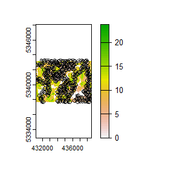

```
#> Simple feature collection with 200 features and 0 fields
#> Geometry type: POINT
#> Dimension:     XY
#> Bounding box:  xmin: 431210 ymin: 5337730 xmax: 438550 ymax: 5343230
#> CRS:           +proj=utm +zone=17 +ellps=GRS80 +towgs84=0,0,0,0,0,0,0 +units=m +no_defs
#> First 10 features:
#>                  geometry
#> 1  POINT (431210 5340970)
#> 2  POINT (437510 5342370)
#> 3  POINT (434190 5342530)
#> 4  POINT (434250 5339450)
#> 5  POINT (435670 5342470)
#> 6  POINT (437930 5338650)
#> 7  POINT (438290 5341030)
#> 8  POINT (434290 5342750)
#> 9  POINT (437770 5338290)
#> 10 POINT (432890 5340370)
```

```r
sample_srs(raster = mraster, # input mraster
           nSamp = 200, # number of desired samples
           access = access, # define access road network
           mindist = 200, # minimum distance samples must be apart from one another
           buff_inner = 50, # inner buffer - no samples within this distance from road
           buff_outer = 200, # outer buffer - no samples further than this distance from road
           plot = TRUE) # plot
```

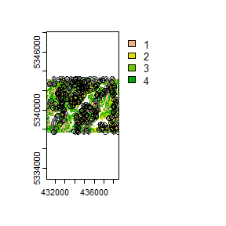

```
#> Writing layer `file4e4450f67e71' to data source
#>   `C:\Users\tgood.stu\AppData\Local\Temp\RtmpQfNpgv\file4e4450f67e71.shp' using driver `ESRI Shapefile'
#> Writing 200 features with 0 fields and geometry type Point.
#> Simple feature collection with 200 features and 0 fields
#> Geometry type: POINT
#> Dimension:     XY
#> Bounding box:  xmin: 431170 ymin: 5337750 xmax: 438470 ymax: 5343230
#> CRS:           +proj=utm +zone=17 +ellps=GRS80 +towgs84=0,0,0,0,0,0,0 +units=m +no_defs
#> First 10 features:
#>                  geometry
#> 1  POINT (434150 5341290)
#> 2  POINT (434150 5341290)
#> 3  POINT (431950 5340650)
#> 4  POINT (433130 5341090)
#> 5  POINT (437770 5338650)
#> 6  POINT (434150 5339370)
#> 7  POINT (435210 5337850)
#> 8  POINT (438030 5342470)
#> 9  POINT (434030 5341310)
#> 10 POINT (434730 5342750)
```

```r
sample_srs(raster = sraster, # input
           nSamp = 200, # number of desired samples
           access = access, # define access road network
           buff_inner = 50, # inner buffer - no samples within this distance from road
           buff_outer = 200, # outer buffer - no samples further than this distance from road
           plot = TRUE, # plot
           filename = tempfile(fileext = ".shp")) # write output samples to file
```

## `sample_systematic`

The `sample_systematic()` function applies systematic sampling across an area where the `cellsize` parameter defines resolution of the tessellation. Tesselation shape options are defined by the `square` parameter, which is a regular grid when `TRUE` (default) and hexagonal when `FALSE`. The location of samples can also be adjusted using the `locations` parameter, where `centers` takes the center, `corners` takes all corners, and `random` takes a random location within each tessellation.

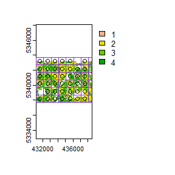

```
#> Simple feature collection with 40 features and 0 fields
#> Geometry type: POINT
#> Dimension:     XY
#> Bounding box:  xmin: 431600 ymin: 5338200 xmax: 437600 ymax: 5343200
#> CRS:           +proj=utm +zone=17 +ellps=GRS80 +towgs84=0,0,0,0,0,0,0 +units=m +no_defs
#> First 10 features:
#>                  geometry
#> 1  POINT (431600 5338200)
#> 2  POINT (432600 5338200)
#> 3  POINT (433600 5338200)
#> 4  POINT (434600 5338200)
#> 5  POINT (435600 5338200)
#> 6  POINT (436600 5338200)
#> 7  POINT (437600 5338200)
#> 8  POINT (432600 5339200)
#> 9  POINT (433600 5339200)
#> 10 POINT (434600 5339200)
```

```r
#--- perform grid sampling ---#
sample_systematic(raster = sraster, # input sraster
                  cellsize = 1000, # grid distance
                  plot = TRUE) # plot
```

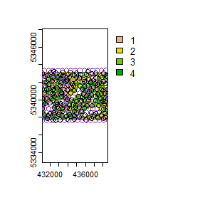

```
#> Simple feature collection with 177 features and 0 fields
#> Geometry type: POINT
#> Dimension:     XY
#> Bounding box:  xmin: 431116.4 ymin: 5337712 xmax: 438524.7 ymax: 5343219
#> CRS:           +proj=utm +zone=17 +ellps=GRS80 +towgs84=0,0,0,0,0,0,0 +units=m +no_defs
#> First 10 features:
#>                    geometry
#> 1  POINT (431155.2 5340130)
#> 2  POINT (431316.8 5341124)
#> 3  POINT (431116.4 5343024)
#> 4  POINT (431333.4 5338295)
#> 5  POINT (431124.7 5338969)
#> 6  POINT (431296.5 5339650)
#> 7  POINT (431325.5 5340814)
#> 8  POINT (431438.7 5341565)
#> 9    POINT (431454 5342621)
#> 10 POINT (431627.6 5337896)
```

```r
#--- perform grid sampling ---#
sample_systematic(raster = sraster, # input sraster
                  cellsize = 500, # grid distance
                  square = FALSE, # hexagonal tessellation
                  location = "random", # random sample within tessellation
                  plot = TRUE) # plot
```

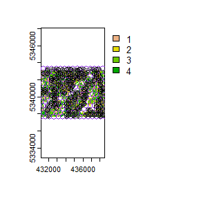

```
#> Simple feature collection with 470 features and 0 fields
#> Geometry type: POINT
#> Dimension:     XY
#> Bounding box:  xmin: 431100 ymin: 5337844 xmax: 438350 ymax: 5343185
#> CRS:           +proj=utm +zone=17 +ellps=GRS80 +towgs84=0,0,0,0,0,0,0 +units=m +no_defs
#> First 10 features:
#>                  geometry
#> 1  POINT (431100 5340875)
#> 2  POINT (431100 5340587)
#> 3  POINT (431100 5340587)
#> 4  POINT (431350 5340442)
#> 5  POINT (431100 5340875)
#> 6  POINT (431100 5340875)
#> 7  POINT (431350 5342752)
#> 8  POINT (431350 5340442)
#> 9  POINT (431100 5340587)
#> 10 POINT (431100 5340875)
```

```r
sample_systematic(raster = sraster, # input sraster
            cellsize = 500, # grid distance
            access = access, # define access road network
            buff_inner = 50, # inner buffer - no samples within this distance from road
            buff_outer = 200, # outer buffer - no samples further than this distance from road
            square = FALSE, # hexagonal tessellation
            location = "corners", # take corners instead of centers
            plot = TRUE)
```

## `sample_strat`

The `sample_strat()` function contains a hierarchical sampling algorithm originally developed my Martin Queinnec.

*Queinnec, M., White, J. C., & Coops, N. C. (2021). Comparing airborne and spaceborne photon-counting LiDAR canopy structural estimates across different boreal forest types. Remote Sensing of Environment, 262(August 2020), 112510.*

The algorithm uses a moving window (`wrow` and `wcol` parameters) to filter the input `sraster` for locations where stratum pixels are spatially grouped rather than dispersed individually across the landscape.

The sampling is performed in 2 stages:

- **Rule 1** - Sample within spatially grouped stratum pixels. Moving window defined by `wrow` and `wcol`.
- **Rule 2** - If no more samples exist to satisfy desired sampling count, individual stratum pixels are sampled.

The rule applied to a select a particular sample is defined in the `rule` attribute of output samples. We give a few examples below:

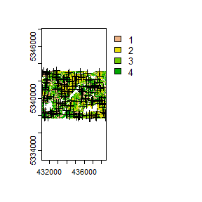

```
#> Simple feature collection with 199 features and 3 fields
#> Geometry type: POINT
#> Dimension:     XY
#> Bounding box:  xmin: 431190 ymin: 5337730 xmax: 438530 ymax: 5343190
#> CRS:           +proj=utm +zone=17 +ellps=GRS80 +towgs84=0,0,0,0,0,0,0 +units=m +no_defs
#> First 10 features:
#>    strata type  rule               geometry
#> x       1  new rule1 POINT (435810 5340790)
#> x1      1  new rule1 POINT (432490 5338130)
#> x2      1  new rule1 POINT (431610 5339550)
#> x3      1  new rule1 POINT (436730 5341390)
#> x4      1  new rule1 POINT (436550 5340670)
#> x5      1  new rule1 POINT (435730 5340790)
#> x6      1  new rule1 POINT (435710 5339870)
#> x7      1  new rule1 POINT (431190 5342870)
#> x8      1  new rule1 POINT (435830 5340350)
#> x9      1  new rule1 POINT (431630 5342910)
```

```r
#--- perform stratified sampling random sampling ---#
sample_strat(sraster = sraster, # input sraster
             nSamp = 200, # desired sample number
             plot = TRUE) # plot
```

In some cases, a user may wish to include an `existing` sample data set within the algorithm. In order to adjust the total number of samples needed per stratum to reflect those already present in `existing`, we can use the utility function `extract_strata()`.

This function takes an input `sraster` and the `existing` sample data set and extracts the stratum for each sample. These samples can then be input into the `sample_strat()` function which adjusts total required sample per class based on representation in `existing`.

```r
#--- extract strata values to existing samples ---#
e.sr <- extract_strata(sraster = sraster, # input sraster
                       existing = existing) # existing samples to add strata value to

e.sr
```

```
#> Simple feature collection with 200 features and 1 field
#> Geometry type: POINT
#> Dimension:     XY
#> Bounding box:  xmin: 431110 ymin: 5337710 xmax: 438550 ymax: 5343230
#> Projected CRS: UTM Zone 17, Northern Hemisphere
#> First 10 features:
#>    strata               geometry
#> 1       2 POINT (435650 5338970)
#> 2       4 POINT (438530 5342930)
#> 3       3 POINT (432190 5338830)
#> 4       4 POINT (438450 5339950)
#> 5       3 POINT (435070 5339650)
#> 6       2 POINT (436290 5338230)
#> 7       4 POINT (438530 5341430)
#> 8       4 POINT (431110 5340210)
#> 9       4 POINT (435110 5341790)
#> 10      3 POINT (438110 5340010)
```

Notice that `e.sr` now has an attribute named strata. If that parameter is not there, `sample_strat()` will give an error.

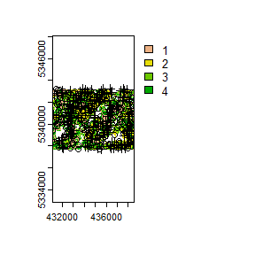

```
#> Simple feature collection with 399 features and 3 fields
#> Geometry type: POINT
#> Dimension:     XY
#> Bounding box:  xmin: 431110 ymin: 5337710 xmax: 438550 ymax: 5343230
#> CRS:           +proj=utm +zone=17 +ellps=GRS80 +towgs84=0,0,0,0,0,0,0 +units=m +no_defs
#> First 10 features:
#>    strata     type     rule               geometry
#> 11      1 existing existing POINT (434070 5339930)
#> 20      1 existing existing POINT (432850 5338270)
#> 29      1 existing existing POINT (431270 5339790)
#> 39      1 existing existing POINT (431770 5341530)
#> 43      1 existing existing POINT (431290 5340190)
#> 49      1 existing existing POINT (438550 5341750)
#> 59      1 existing existing POINT (432870 5339990)
#> 62      1 existing existing POINT (433770 5339590)
#> 81      1 existing existing POINT (434070 5338090)
#> 83      1 existing existing POINT (431490 5340050)
```

```r
sample_strat(sraster = sraster, # input sraster
             nSamp = 200, # desired sample number
             access = access, # define access road network
             existing = e.sr, # existing samples with strata values
             mindist = 200, # minimum distance samples must be apart from one another
             buff_inner = 50, # inner buffer - no samples within this distance from road
             buff_outer = 200, # outer buffer - no samples further than this distance from road
             plot = TRUE) # plot
```

The `mindist` parameter defined in the above example specifies the minimum euclidian distance that samples must be apat from one another.

Notice that the sample outputs have `type` and `rule` attributes which outline whether samples are `existing` or `new` and whether `rule1` or `rule2` were used to select individual samples.

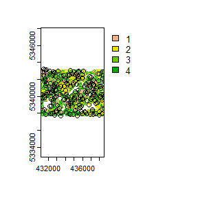

```
#> Writing layer `file4e446ac412fe' to data source
#>   `C:\Users\tgood.stu\AppData\Local\Temp\RtmpQfNpgv\file4e446ac412fe.shp' using driver `ESRI Shapefile'
#> Writing 199 features with 3 fields and geometry type Point.
#> Simple feature collection with 199 features and 3 fields
#> Geometry type: POINT
#> Dimension:     XY
#> Bounding box:  xmin: 431110 ymin: 5337710 xmax: 438550 ymax: 5343230
#> CRS:           +proj=utm +zone=17 +ellps=GRS80 +towgs84=0,0,0,0,0,0,0 +units=m +no_defs
#> First 10 features:
#>    strata     type     rule               geometry
#> 11      1 existing existing POINT (434070 5339930)
#> 20      1 existing existing POINT (432850 5338270)
#> 29      1 existing existing POINT (431270 5339790)
#> 39      1 existing existing POINT (431770 5341530)
#> 43      1 existing existing POINT (431290 5340190)
#> 49      1 existing existing POINT (438550 5341750)
#> 59      1 existing existing POINT (432870 5339990)
#> 62      1 existing existing POINT (433770 5339590)
#> 81      1 existing existing POINT (434070 5338090)
#> 83      1 existing existing POINT (431490 5340050)
```

```r
sample_strat(sraster = sraster, # input
             nSamp = 200, # desired sample number
             access = access, # define access road network
             existing = e.sr, # existing samples with strata values
             include = TRUE, # include existing plots in nSamp total
             buff_inner = 50, # inner buffer - no samples within this distance from road
             buff_outer = 200, # outer buffer - no samples further than this distance from road
             filename = tempfile(fileext = ".shp"), # write output samples to file
             plot = TRUE) # plot
```

The `include` parameter determines whether existing samples should be included in the total count of samples defined by `nSamp`. By defaults `include = FALSE`.

## `sample_clhs`

The `sample_clhs()` function implements conditioned latin hypercube (clhs) sampling functionality. A number of other functions in the `sgsR` package help to provide guidance on clhs sampling including `calculate_lhsPop()` and `calculate_lhsOpt()`. Be sure to check out those functions for better understanding of how to optimize sample numbers.

Syntax for this function is similar to others shown above, though parameters like `iter`, which define the number of iterations within the Metropolis-Hastings process are important to consider. In these examples we use a low `iter` value because it takes less time to run. Default values for `iter` within the `clhs` package are 10,000.

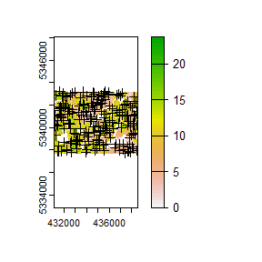

```r
sample_clhs(mraster = mraster, # input
            nSamp = 200, # desired sample number
            plot = TRUE, # plot
            iter = 100) # number of iterations
```

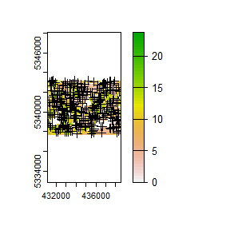

```r
sample_clhs(mraster = mraster, # input
            nSamp = 300, # desired sample number
            existing = existing, # existing samples
            iter = 100, # number of iterations
            details = TRUE, # output details
            plot = TRUE) # clhs details
```

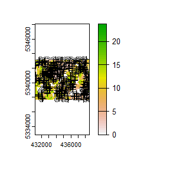

```r
sample_clhs(mraster = mraster, # input
            nSamp = 300, # desired sample number
            iter = 100, # number of iterations
            existing = existing, # existing samples
            access = access, # define access road network
            buff_inner = 100, # inner buffer - no samples within this distance from road
            buff_outer = 300, # outer buffer - no samples further than this distance from road
            plot = TRUE) # plot
```

The `cost` parameter defines an `mraster` covariate to be used to constrain the clhs sampling. This could be any number of variables. An example could be the distance a pixel is from road access (see example below), terrain slope, the output from `calculate_coobs()`, or many others.

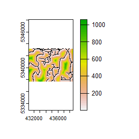

```r
#--- cost constrained examples ---#
#--- calculate distance to access layer for each pixel in mr ---#
mr.c <- calculate_distance(raster = mraster, # input
                           access = access,
                           plot = TRUE) # define access road network
```

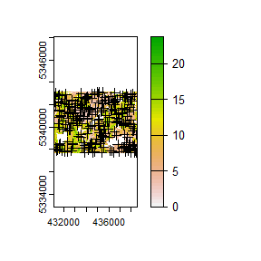

```r
sample_clhs(mraster = mr.c, # input
            nSamp = 250, # desired sample number
            iter = 100, # number of iterations
            cost = "dist2access", # cost parameter - name defined in calculate_distance()
            plot = TRUE) # plot
```

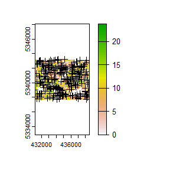

```r
sample_clhs(mraster = mr.c, # input
            nSamp = 250, # desired sample number
            existing = existing, # existing samples
            iter = 100, # number of iterations
            cost = "dist2access", # cost parameter - name defined in calculate_distance()
            plot = TRUE) # plot
```

## `sample_balanced`

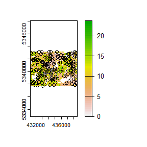

```
#> Simple feature collection with 200 features and 0 fields
#> Geometry type: POINT
#> Dimension:     XY
#> Bounding box:  xmin: 431150 ymin: 5337730 xmax: 438550 ymax: 5343170
#> CRS:           +proj=utm +zone=17 +ellps=GRS80 +towgs84=0,0,0,0,0,0,0 +units=m +no_defs
#> First 10 features:
#>                  geometry
#> 1  POINT (434310 5343170)
#> 2  POINT (435330 5343170)
#> 3  POINT (434090 5343150)
#> 4  POINT (432510 5343110)
#> 5  POINT (432890 5343110)
#> 6  POINT (438130 5343110)
#> 7  POINT (431150 5343010)
#> 8  POINT (438290 5343010)
#> 9  POINT (438510 5342990)
#> 10 POINT (431650 5342850)
```

```r
sample_balanced(mraster = mraster, # input
                nSamp = 200, # desired sample number
                plot = TRUE) # plot
```

```r
sample_balanced(mraster = mraster, # input
                nSamp = 100, # desired sample number
                algorithm = "lcube", # algorithm type
                access = access, # define access road network
                buff_inner = 50, # inner buffer - no samples within this distance from road
                buff_outer = 200) # outer buffer - no samples further than this distance from road
```

```
#> Simple feature collection with 100 features and 0 fields
#> Geometry type: POINT
#> Dimension:     XY
#> Bounding box:  xmin: 431130 ymin: 5337810 xmax: 438530 ymax: 5343230
#> CRS:           +proj=utm +zone=17 +ellps=GRS80 +towgs84=0,0,0,0,0,0,0 +units=m +no_defs
#> First 10 features:
#>                  geometry
#> 1  POINT (432650 5339110)
#> 2  POINT (434830 5337930)
#> 3  POINT (438510 5338090)
#> 4  POINT (432750 5339470)
#> 5  POINT (435650 5338910)
#> 6  POINT (438350 5340490)
#> 7  POINT (435350 5339890)
#> 8  POINT (432070 5343110)
#> 9  POINT (431930 5342530)
#> 10 POINT (434270 5338130)
```

## `sample_ahels`

The `sample_ahels()` function performs the adapted Hypercube Evaluation of a Legacy Sample (ahels) algorithm using `existing` sample data and an `mraster`. New samples are allocated based on quantile ratios between the `existing` sample and `mraster` covariate dataset.

This algorithm:

1. Determines the quantile distributions of `existing` samples and `mraster` covariates.
2. Determines quantiles where there is a disparity between samples and covariates.
3. Prioritizes sampling within those quantile to improve representation.

To use the function, the user will first specify the number of quantiles (`nQuant`) followed by either the `nSamp` (total number of desired samples to be added) or `threshold` (proportional representation between sample and covariate quantiles - default is 0.9) parameters. Its recommended to use `threshold` values at or below 0.9 as higher values can currently cause the algorithm to add samples repeatedly.

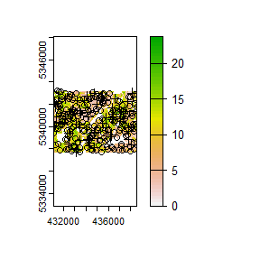

```
#> Simple feature collection with 268 features and 4 fields
#> Geometry type: POINT
#> Dimension:     XY
#> Bounding box:  xmin: 431110 ymin: 5337710 xmax: 438550 ymax: 5343230
#> CRS:           +proj=utm +zone=17 +ellps=GRS80 +towgs84=0,0,0,0,0,0,0 +units=m +no_defs
#> First 10 features:
#>        type  zmax zmean  zsd               geometry
#> 1  existing  5.36  50.5 2.54 POINT (435650 5338970)
#> 2  existing 10.54  88.1 4.67 POINT (438530 5342930)
#> 3  existing  6.30  62.9 3.87 POINT (432190 5338830)
#> 4  existing 12.05  92.0 5.16 POINT (438450 5339950)
#> 5  existing  5.93  29.6 2.96 POINT (435070 5339650)
#> 6  existing  5.23  91.9 2.24 POINT (436290 5338230)
#> 7  existing  9.92  65.4 5.13 POINT (438530 5341430)
#> 8  existing 11.07  94.6 3.58 POINT (431110 5340210)
#> 9  existing  9.98  86.7 4.51 POINT (435110 5341790)
#> 10 existing  7.92  99.3 4.07 POINT (438110 5340010)
```

```r
sample_ahels(mraster = mraster[[1:3]], # input mraster - first 3 layers only
             existing = existing, # existing samples
             plot = TRUE) # plot
```

Notice that no `threshold`, `nSamp`, or `nQuant` were defined. Thats because defaults are `threshold = 0.9` and `nQuant = 10`.

[figure not shown]

```
#> Simple feature collection with 500 features and 4 fields
#> Geometry type: POINT
#> Dimension:     XY
#> Bounding box:  xmin: 431110 ymin: 5337710 xmax: 438550 ymax: 5343230
#> CRS:           +proj=utm +zone=17 +ellps=GRS80 +towgs84=0,0,0,0,0,0,0 +units=m +no_defs
#> First 10 features:
#>        type  zmax zmean  zsd               geometry
#> 1  existing  5.36  50.5 2.54 POINT (435650 5338970)
#> 2  existing 10.54  88.1 4.67 POINT (438530 5342930)
#> 3  existing  6.30  62.9 3.87 POINT (432190 5338830)
#> 4  existing 12.05  92.0 5.16 POINT (438450 5339950)
#> 5  existing  5.93  29.6 2.96 POINT (435070 5339650)
#> 6  existing  5.23  91.9 2.24 POINT (436290 5338230)
#> 7  existing  9.92  65.4 5.13 POINT (438530 5341430)
#> 8  existing 11.07  94.6 3.58 POINT (431110 5340210)
#> 9  existing  9.98  86.7 4.51 POINT (435110 5341790)
#> 10 existing  7.92  99.3 4.07 POINT (438110 5340010)
```

```r
sample_ahels(mraster = mraster[[1:3]], # input mraster - first 3 layers only
             existing = existing, # existing samples
             nQuant = 20, # define 20 quantiles
             nSamp = 300, # total samples desired
             filename = tempfile(fileext = ".shp")) # write samples to disc
```

Note that the total number of samples is 500. This is the total of existing samples (200) and the number defined by `nSamp = 300`.